# Homework 1

David (Yuandong) Sun

UCLA Stats 401

Do not post your homework solutions online.

# Reading

- Chapter 5 from R for Data Science available at: http://r4ds.had.co.nz/transform.html
- HSAUR Chapter 3 Simple Inference
- ISwR Chapter 5 One and Two-sample test
- ISwR Chapter 6.4 Correlation Tests
- ISwR Chapter 8 Tabular Data

# Exercise 1

The data come from the following journal article, referenced by Samuels, et al. There were many treatments used, but for the purpose of this assignment, some of the treatments have been combined.

Pappas, T., & Mitchell, C. A. (1985). Effects of seismic stress on the vegetative growth of Glycine max (L.) Merr. cv. Wells II. Plant, cell & environment, 8(2), 143-148.

http://onlinelibrary.wiley.com/doi/10.1111/j.1365-3040.1985.tb01221.x/epdf

A plant physiologist conducted an experiment to determine whether mechanical stress can slow the growth of soybean plants. Young plants were randomly allocated to two groups of 13 plants each. Plants in one group were mechanically agitated by shaking for 20 minutes twice daily, while plants in the other group were not agitated. After 16 days of growth, the total stem length (cm) of each plant was measured, with the results given in the accompanying table.

```r
ex1 <- read.csv('HW1Ex1.csv')
head(ex1)
```

```
##   StemLength Treatment
## 1       25.2   control
## 2       29.5   control
## 3       30.1   control
## 4       30.1   control
## 5       30.2   control
## 6       30.2   control
```

## Part 1

Use a t-test to compare the treatments at alpha = 0.01. Let the alternative hypothesis be that stress tends to **slow growth.**

H0: $\mu$_control - $\mu$_stress = 0

Ha: $\mu$_control - $\mu$_stress > 0

```r
tapply(ex1$StemLength,ex1$Treatment,var)
```

```
##  control   stress
## 4.552436 2.980256
```

```r
t.test(StemLength ~ Treatment, data = ex1,val.equal = F,alternative = "greater",conf.level = 0.99)
```

```
##
##  Welch Two Sample t-test
##
## data:  StemLength by Treatment
## t = 3.6986, df = 22.998, p-value = 0.0005928
## alternative hypothesis: true difference in means is greater than 0
## 99 percent confidence interval:
##  0.9124544       Inf
## sample estimates:
## mean in group control  mean in group stress
##              30.59231              27.77692
```

From the variance results, we see the variances are different and thus we use Welch two sample t-test. We get the P-value = 0.0005928 < 0.01, we reject H0 and conclude that there is sufficient evidence to support the stress tends to slow growth.

## Part 2

Construct a 95% confidence interval for the population mean reduction in stem length.

```r
t.test(StemLength ~ Treatment, data = ex1,equal = F, alternative = "two.sided",conf.level = 0.95)
```

```
##
##  Welch Two Sample t-test
##
## data:  StemLength by Treatment
## t = 3.6986, df = 22.998, p-value = 0.001186
## alternative hypothesis: true difference in means is not equal to 0
## 95 percent confidence interval:
##  1.240699 4.390071
## sample estimates:
## mean in group control  mean in group stress
##              30.59231              27.77692
```

Answer:

95% CI: [1.240699, 4.390071]

Does the confidence interval indicate whether the effect of stress is “horticulturally important,” if “horticulturally important” is defined as a reduction in population mean stem length of at least 1 cm?

Answer: The CI **indicates** the effect of stress is “horticulturally important” if it is defined as a reduction in population mean stem length of at least 1 cm, which is inclusive in the 95% CI.

Does the confidence interval indicate whether the effect of stress is “horticulturally important,” if “horticulturally important” is defined as a reduction in population mean stem length of at least 5 cm?

Answer: The CI **does not indicate** the effect of stress is “horticulturally important” if it is defined as a reduction in population mean stem length of at least 5 cm, since 5cm is not included in the 95% CI.

## Part 3

Compare the treatments using a Wilcoxon-Mann-Whitney test at alpha = 0.01. Let the alternative hypothesis be that stress tends to **slow growth.** H0: $\mu$_control - $\mu$_stress = 0

Ha: $\mu$_control - $\mu$_stress >0

```r
wilcox.test(StemLength~ Treatment, data = ex1,alternative = "greater",conf.level =0.99)
```

```
##
##  Wilcoxon rank sum test with continuity correction
##
## data:  StemLength by Treatment
## W = 148.5, p-value = 0.0005608
## alternative hypothesis: true location shift is greater than 0
```

From the above test, we get P- value = 0.0005608 < 0.01, we reject H0 and thus conclude that there is sufficient evidence to support the stress tends to slow growth.

# Exercise 2

The data is based on the following journal article, referenced by Samuels, et al..

Sargent, P. A., Sharpley, A. L., Williams, C., Goodall, E. M., & Cowen, P. J. (1997). 5-HT2C receptor activation decreases appetite and body weight in obese subjects. Psychopharmacology, 133, 309-312.

https://www.researchgate.net/profile/Ann_Sharpley/publication/13869188_5-HT2C_activation_decreases_appetite_and_body_weight_in_obese_subjects/links/559275b908ae47a34910f4ba.pdf

## Part 1

During a weight loss study, each of nine female subjects was given

1. the active drug m-chlorophenylpiperazine (mCPP) for two weeks and then a placebo for another two weeks, or
2. the placebo for the first two weeks and then mCPP for the second two weeks. The data shows the amount of weight loss (kg) for the nine subjects when taking the drug mCPP and when taking a placebo. (Note that if a subject gained weight, then the recorded weight loss is negative, as is the case for subject 2 who gained 0.3 kg when on the placebo.)

Use a t-test to investigate the claim that mCPP affects weight loss. Let HA be nondirectional and let alpha = 0.01.

H0: $\mu$_mcpp = $\mu$_placebo

Ha: $\mu$_mcpp $\ne$ $\mu$_placebo

```r
ex2 <- read.csv('HW1Ex2Part1.csv')

t.test(ex2$mCPP,ex2$Placebo, paired = TRUE, alternative = "two.sided",conf.level = 0.99)
```

```
##
##  Paired t-test
##
## data:  ex2$mCPP and ex2$Placebo
## t = 4.1703, df = 8, p-value = 0.003121
## alternative hypothesis: true difference in means is not equal to 0
## 99 percent confidence interval:
##  0.1954064 1.8045936
## sample estimates:
## mean of the differences
##                       1
```

## Part 2

The same study included a group of nine men. They were randomly assigned treatments in a similar way to the women in part 1. For each man two measurements were made: weight change when taking mCPP and weight change when taking the placebo.

Analyze the data with a Wilcoxon signed-rank test at the alpha = 0.05 level; use a nondirectional alternative with alpha = 0.05

H0: $\mu$_mcpp = $\mu$_placebo

Ha: $\mu$_mcpp $\ne$ $\mu$_placebo

```r
ex2p2 <- read.csv('HW1Ex2Part2.csv')

wilcox.test(ex2p2$mCPP,ex2p2$Placebo,paired= TRUE)
```

```
##
##  Wilcoxon signed rank exact test
##
## data:  ex2p2$mCPP and ex2p2$Placebo
## V = 15, p-value = 0.4258
## alternative hypothesis: true location shift is not equal to 0
```

From the aboved test result, we get p- value = 0.4258 > 0.05, we accept H0:$\mu$_mCPP is equal to $\mu$_Placebo, and thus conclude that there is sufficient evidence to support mCPP does not affect weight loss

# Exercise 3

The data is based on the following journal article, referenced by Samuels, et al.

Ware, J. H. (1989). Investigating therapies of potentially great benefit: ECMO. Statistical Science, 298-306.

http://www.jstor.org/stable/2245829?seq=1#page_scan_tab_contents

Extracorporeal membrane oxygenation (ECMO) is a procedure that is used to treat newborn babies who suffer from severe respiratory failure. An experiment was conducted in which 29 babies were treated with ECMO and 10 babies were treated with conventional medical therapy (CMT). The outcomes of this study are shown here

```r
ex3 <- data.frame(
  outcome = c(rep('Die',4), rep('Live',6), rep('Die',1), rep('Live',28)),
  treatment = c(rep('CMT',10), rep('ECMO',29))
)
addmargins(table(ex3))
```

```
##        treatment
## outcome CMT ECMO Sum
##    Die    4    1   5
##    Live   6   28  34
##    Sum   10   29  39
```

## Part 1

Why is the chi-squared test not appropriate for this study?

Answer: Because some counts of cells are below 5, the assumptions regarding the Chi-squared distribution may not be true.

## Part 2

Perform a randomization test (with at least 5000 randomizations) to test if ECMO is more effective at saving the lives of newborn babies with respiratory failure.

H0: $\mu$_ECMO = $\mu$_CMT

Ha: $\mu$_ECMO $\gt$ $\mu$_CMT

```r
record<-ex3$outcome
record_convert <- ifelse(record=="Live",T,F)

cmt <- record_convert[1:10]
mean(cmt)
```

```
## [1] 0.6
```

```r
ecmo <- record_convert[11:39]
mean(ecmo)
```

```
## [1] 0.9655172
```

```r
obs_dif <- mean(ecmo)-mean(cmt)
obs_dif
```

```
## [1] 0.3655172
```

```r
#randomization
set.seed(1)
group_mean_diff<-rep(NA,5000)
for(i in 1:5000){
  randomized <-sample(record_convert)
  group_cmt <-randomized[1:10]
  group_ecmo <- randomized[11:39]
  group_mean_diff[i] <- mean(group_ecmo)-mean(group_cmt)
}
summary(group_mean_diff)
```

```
##       Min.    1st Qu.     Median       Mean    3rd Qu.       Max.
## -0.1724138 -0.0379310 -0.0379310 -0.0007062  0.0965517  0.5000000
```

```r
mean(group_mean_diff>=obs_dif)
```

```
## [1] 0.0096
```

From the above test result, we get the empirical p-value 0.0096< 0.05, so reject H0 and conclude that there is sufficient evidence to support Ha that ECMO is more effective at saving the lives of newborn babies with respiratory failure.

## Part 3

Use Fisher’s exact test to test if ECMO is more effective at saving the lives of newborn babies with respiratory failure. Use alpha = 0.05.

H0: $\mu$_ECMO = $\mu$_CMT

Ha: $\mu$_ECMO $\gt$ $\mu$_CMT

```r
fisher.test(table(ex3),alt = "greater")
```

```
##
##  Fisher's Exact Test for Count Data
##
## data:  table(ex3)
## p-value = 0.01102
## alternative hypothesis: true odds ratio is greater than 1
## 95 percent confidence interval:
##  1.833681      Inf
## sample estimates:
## odds ratio
##   16.78571
```

From the above test result, we get p-value = 0.01102 < 0.05, thus there is sufficient evidence to reject H0 and conclude that there is sufficient evidence to support Ha that ECMO is more effective at saving the lives of newborn babies with respiratory failure.

# Exercise 4

The data is based on the following journal article, referenced by Samuels, et al.

Johnson, S. K., & Johnson, R. E. (1972). Tonsillectomy history in Hodgkin’s disease. New England Journal of Medicine, 287(22), 1122-1125.

http://www.nejm.org/doi/full/10.1056/NEJM197211302872205#t=articleTop

A study of 85 patients with Hodgkin’s disease found that 41 had had their tonsils removed. Each patient was matched with a sibling of the same sex. Only 33 of the siblings had undergone tonsillectomy. The data are shown in the following table.

```r
ex4 <- data.frame(
  hodkins = c(rep('yes',26), rep('no',7), rep('yes',15), rep('no',37)),
  sibling = c(rep('yes',33), rep('no',52))
)
table(ex4)
```

```
##        sibling
## hodkins no yes
##     no  37   7
##     yes 15  26
```

Use McNemar’s test to test the hypothesis that “yes/no” and “no/yes” pairs are equally likely. Previous research had suggested that having a tonsillectomy is associated with an **increased** risk of Hodgkin’s disease; thus, use a directional alternative. Let a = 0.05

H0: P_“yes/no” = P_“no/yes”

Ha: P_“yes/no” $\gt$ P_“no/yes”

```r
mcnemar.test(table(ex4),correct = F)
```

```
##
##  McNemar's Chi-squared test
##
## data:  table(ex4)
## McNemar's chi-squared = 2.9091, df = 1, p-value = 0.08808
```

```r
tst<-mcnemar.test(table(ex4),correct = F)
tst$p.value/2
```

```
## [1] 0.04404076
```

From the above test result, we get p-value= 0.08808, but since it is directional, the p-value should be divided by 2, which is 0.04404 < 0.05. we do not accept H0：P_“yes/no” = P_“no/yes” . There is sufficient evidence to support having a tonsillectomy is associated with an increased risk of Hodgkin’s disease.

# Exercise 5 - dplyr

These exercises are taken from Wickham’s R for Data Science book chapter 5. The data comes from the package `library(nycflights13)`

```r
# install.packages('nycflights13')
ex5<-library(nycflights13)
library(dplyr)
```

### From section 5.2.4

#### 1:

Find all flights that

```r
# - Had an arrival delay of two or more hours
flights %>%
    filter(arr_delay >=120)
```

```
## # A tibble: 10,200 x 19
##     year month   day dep_time sched_dep_time dep_delay arr_time sched_arr_time
##    <int> <int> <int>    <int>          <int>     <dbl>    <int>          <int>
##  1  2013     1     1      811            630       101     1047            830
##  2  2013     1     1      848           1835       853     1001           1950
##  3  2013     1     1      957            733       144     1056            853
##  4  2013     1     1     1114            900       134     1447           1222
##  5  2013     1     1     1505           1310       115     1638           1431
##  6  2013     1     1     1525           1340       105     1831           1626
##  7  2013     1     1     1549           1445        64     1912           1656
##  8  2013     1     1     1558           1359       119     1718           1515
##  9  2013     1     1     1732           1630        62     2028           1825
## 10  2013     1     1     1803           1620       103     2008           1750
## # ... with 10,190 more rows, and 11 more variables: arr_delay <dbl>,
## #   carrier <chr>, flight <int>, tailnum <chr>, origin <chr>, dest <chr>,
## #   air_time <dbl>, distance <dbl>, hour <dbl>, minute <dbl>, time_hour <dttm>
```

```r
# - Flew to Houston (IAH or HOU)
flights %>%
    filter(dest == "IAH" | dest == "HOU")
```

```
## # A tibble: 9,313 x 19
##     year month   day dep_time sched_dep_time dep_delay arr_time sched_arr_time
##    <int> <int> <int>    <int>          <int>     <dbl>    <int>          <int>
##  1  2013     1     1      517            515         2      830            819
##  2  2013     1     1      533            529         4      850            830
##  3  2013     1     1      623            627        -4      933            932
##  4  2013     1     1      728            732        -4     1041           1038
##  5  2013     1     1      739            739         0     1104           1038
##  6  2013     1     1      908            908         0     1228           1219
##  7  2013     1     1     1028           1026         2     1350           1339
##  8  2013     1     1     1044           1045        -1     1352           1351
##  9  2013     1     1     1114            900       134     1447           1222
## 10  2013     1     1     1205           1200         5     1503           1505
## # ... with 9,303 more rows, and 11 more variables: arr_delay <dbl>,
## #   carrier <chr>, flight <int>, tailnum <chr>, origin <chr>, dest <chr>,
## #   air_time <dbl>, distance <dbl>, hour <dbl>, minute <dbl>, time_hour <dttm>
```

```r
# - Were operated by United, American, or Delta
flights %>%
    filter(carrier == "UA" |carrier == "AA"|carrier == "DL")
```

```
## # A tibble: 139,504 x 19
##     year month   day dep_time sched_dep_time dep_delay arr_time sched_arr_time
##    <int> <int> <int>    <int>          <int>     <dbl>    <int>          <int>
##  1  2013     1     1      517            515         2      830            819
##  2  2013     1     1      533            529         4      850            830
##  3  2013     1     1      542            540         2      923            850
##  4  2013     1     1      554            600        -6      812            837
##  5  2013     1     1      554            558        -4      740            728
##  6  2013     1     1      558            600        -2      753            745
##  7  2013     1     1      558            600        -2      924            917
##  8  2013     1     1      558            600        -2      923            937
##  9  2013     1     1      559            600        -1      941            910
## 10  2013     1     1      559            600        -1      854            902
## # ... with 139,494 more rows, and 11 more variables: arr_delay <dbl>,
## #   carrier <chr>, flight <int>, tailnum <chr>, origin <chr>, dest <chr>,
## #   air_time <dbl>, distance <dbl>, hour <dbl>, minute <dbl>, time_hour <dttm>
```

```r
# - Departed in summer (July, August, and September)
flights %>%
    filter(month %in% c(7,8,9))
```

```
## # A tibble: 86,326 x 19
##     year month   day dep_time sched_dep_time dep_delay arr_time sched_arr_time
##    <int> <int> <int>    <int>          <int>     <dbl>    <int>          <int>
##  1  2013     7     1        1           2029       212      236           2359
##  2  2013     7     1        2           2359         3      344            344
##  3  2013     7     1       29           2245       104      151              1
##  4  2013     7     1       43           2130       193      322             14
##  5  2013     7     1       44           2150       174      300            100
##  6  2013     7     1       46           2051       235      304           2358
##  7  2013     7     1       48           2001       287      308           2305
##  8  2013     7     1       58           2155       183      335             43
##  9  2013     7     1      100           2146       194      327             30
## 10  2013     7     1      100           2245       135      337            135
## # ... with 86,316 more rows, and 11 more variables: arr_delay <dbl>,
## #   carrier <chr>, flight <int>, tailnum <chr>, origin <chr>, dest <chr>,
## #   air_time <dbl>, distance <dbl>, hour <dbl>, minute <dbl>, time_hour <dttm>
```

```r
# - Arrived more than two hours late, but didn't leave late
flights %>%
    filter(arr_delay>=120,dep_delay <=0 )
```

```
## # A tibble: 29 x 19
##     year month   day dep_time sched_dep_time dep_delay arr_time sched_arr_time
##    <int> <int> <int>    <int>          <int>     <dbl>    <int>          <int>
##  1  2013     1    27     1419           1420        -1     1754           1550
##  2  2013    10     7     1350           1350         0     1736           1526
##  3  2013    10     7     1357           1359        -2     1858           1654
##  4  2013    10    16      657            700        -3     1258           1056
##  5  2013    11     1      658            700        -2     1329           1015
##  6  2013     3    18     1844           1847        -3       39           2219
##  7  2013     4    17     1635           1640        -5     2049           1845
##  8  2013     4    18      558            600        -2     1149            850
##  9  2013     4    18      655            700        -5     1213            950
## 10  2013     5    22     1827           1830        -3     2217           2010
## # ... with 19 more rows, and 11 more variables: arr_delay <dbl>, carrier <chr>,
## #   flight <int>, tailnum <chr>, origin <chr>, dest <chr>, air_time <dbl>,
## #   distance <dbl>, hour <dbl>, minute <dbl>, time_hour <dttm>
```

```r
# - Were delayed by at least an hour, but made up over 30 minutes in flight
flights %>%
  filter(dep_delay>=60,(dep_delay- arr_delay)>30 )
```

```
## # A tibble: 1,844 x 19
##     year month   day dep_time sched_dep_time dep_delay arr_time sched_arr_time
##    <int> <int> <int>    <int>          <int>     <dbl>    <int>          <int>
##  1  2013     1     1     2205           1720       285       46           2040
##  2  2013     1     1     2326           2130       116      131             18
##  3  2013     1     3     1503           1221       162     1803           1555
##  4  2013     1     3     1839           1700        99     2056           1950
##  5  2013     1     3     1850           1745        65     2148           2120
##  6  2013     1     3     1941           1759       102     2246           2139
##  7  2013     1     3     1950           1845        65     2228           2227
##  8  2013     1     3     2015           1915        60     2135           2111
##  9  2013     1     3     2257           2000       177       45           2224
## 10  2013     1     4     1917           1700       137     2135           1950
## # ... with 1,834 more rows, and 11 more variables: arr_delay <dbl>,
## #   carrier <chr>, flight <int>, tailnum <chr>, origin <chr>, dest <chr>,
## #   air_time <dbl>, distance <dbl>, hour <dbl>, minute <dbl>, time_hour <dttm>
```

```r
# - Departed between midnight and 6am (inclusive)
flights %>%
  filter((dep_time >=001 & dep_time <=600) | dep_time ==2400)
```

```
## # A tibble: 9,373 x 19
##     year month   day dep_time sched_dep_time dep_delay arr_time sched_arr_time
##    <int> <int> <int>    <int>          <int>     <dbl>    <int>          <int>
##  1  2013     1     1      517            515         2      830            819
##  2  2013     1     1      533            529         4      850            830
##  3  2013     1     1      542            540         2      923            850
##  4  2013     1     1      544            545        -1     1004           1022
##  5  2013     1     1      554            600        -6      812            837
##  6  2013     1     1      554            558        -4      740            728
##  7  2013     1     1      555            600        -5      913            854
##  8  2013     1     1      557            600        -3      709            723
##  9  2013     1     1      557            600        -3      838            846
## 10  2013     1     1      558            600        -2      753            745
## # ... with 9,363 more rows, and 11 more variables: arr_delay <dbl>,
## #   carrier <chr>, flight <int>, tailnum <chr>, origin <chr>, dest <chr>,
## #   air_time <dbl>, distance <dbl>, hour <dbl>, minute <dbl>, time_hour <dttm>
```

### From section 5.5.2

#### 1

Currently dep_time and sched_dep_time are convenient to look at, but hard to compute with because they’re not really continuous numbers. Convert them to a more convenient representation of number of minutes since midnight.

```r
flights_n<-flights
flights_n$dep_time <- ifelse(flights_n$dep_time==2400,0,flights_n$dep_time)
flights_n$sched_dep_time<- ifelse(flights_n$sched_dep_time==2400,0,flights_n$sched_dep_time)

flights_n%>%
  mutate(dep_time = (dep_time %/% 100 *60 + dep_time %%100), sched_dep_time = (sched_dep_time %/% 100 *60 + sched_dep_time %%100))
```

```
## # A tibble: 336,776 x 19
##     year month   day dep_time sched_dep_time dep_delay arr_time sched_arr_time
##    <int> <int> <int>    <dbl>          <dbl>     <dbl>    <int>          <int>
##  1  2013     1     1      317            315         2      830            819
##  2  2013     1     1      333            329         4      850            830
##  3  2013     1     1      342            340         2      923            850
##  4  2013     1     1      344            345        -1     1004           1022
##  5  2013     1     1      354            360        -6      812            837
##  6  2013     1     1      354            358        -4      740            728
##  7  2013     1     1      355            360        -5      913            854
##  8  2013     1     1      357            360        -3      709            723
##  9  2013     1     1      357            360        -3      838            846
## 10  2013     1     1      358            360        -2      753            745
## # ... with 336,766 more rows, and 11 more variables: arr_delay <dbl>,
## #   carrier <chr>, flight <int>, tailnum <chr>, origin <chr>, dest <chr>,
## #   air_time <dbl>, distance <dbl>, hour <dbl>, minute <dbl>, time_hour <dttm>
```

### From section 5.6.7

#### 4

Look at the number of cancelled flights per day. Is there a pattern? Is the proportion of cancelled flights related to the average delay?

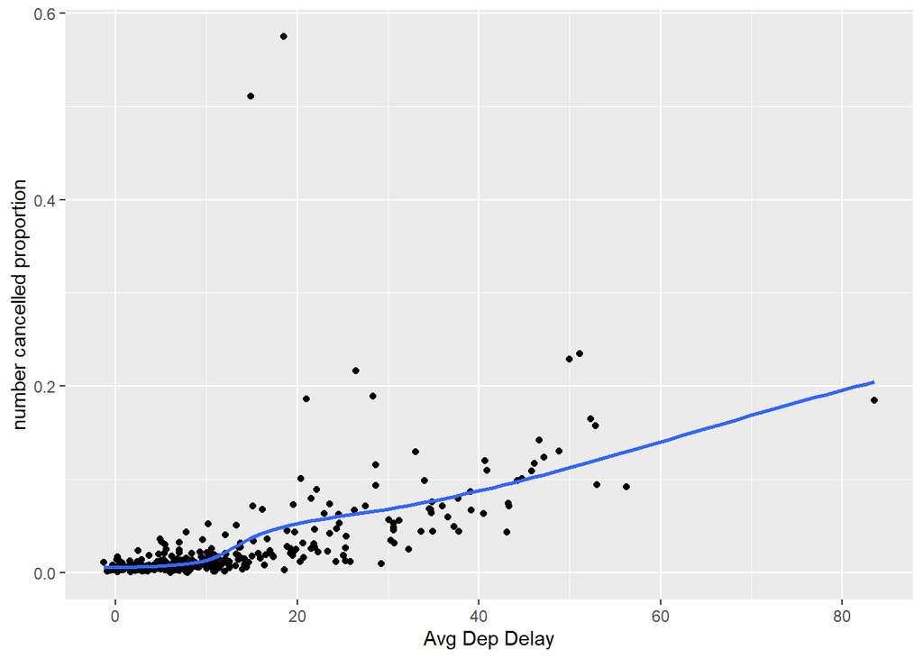

```r
library(ggplot2)
flights %>%
  mutate(date = as.Date(paste(year, month, day, sep='-')))%>%
  group_by(date)%>%
  summarise(num_cancel=sum(is.na(arr_delay)),n=n(),avg_dep_delay = mean(dep_delay, na.rm=TRUE),avg_arr_delay = mean(arr_delay, na.rm=TRUE)) %>%
  ggplot(mapping = aes(x=avg_dep_delay, y = (num_cancel/n)))+geom_point()+geom_smooth(se=FALSE)+labs(x= "Avg Dep Delay",y= "number cancelled proportion")
```

It seems like there is a positive correlation between average depart delay and number canceled proportion per day. The higher average depart delay is, the higher number canceled proportion per day.

#### 5

Which carrier has the worst delays? (ignore the challenge section)

```r
flights %>%
  group_by(carrier)%>%
  summarise(n=n(),avg_dep_delay = mean(dep_delay, na.rm=TRUE),avg_arr_delay = mean(arr_delay, na.rm=TRUE))%>%
  arrange(desc(avg_dep_delay))
```

```
## # A tibble: 16 x 4
##    carrier     n avg_dep_delay avg_arr_delay
##    <chr>   <int>         <dbl>         <dbl>
##  1 F9        685         20.2         21.9
##  2 EV      54173         20.0         15.8
##  3 YV        601         19.0         15.6
##  4 FL       3260         18.7         20.1
##  5 WN      12275         17.7          9.65
##  6 9E      18460         16.7          7.38
##  7 B6      54635         13.0          9.46
##  8 VX       5162         12.9          1.76
##  9 OO         32         12.6         11.9
## 10 UA      58665         12.1          3.56
## 11 MQ      26397         10.6         10.8
## 12 DL      48110          9.26         1.64
## 13 AA      32729          8.59         0.364
## 14 AS        714          5.80        -9.93
## 15 HA        342          4.90        -6.92
## 16 US      20536          3.78         2.13
```

Answer: F9 has the worst average departure delay and average arrival delay.